# Assignment2_q5

Soham Sengupta

15/11/2022

## Problem 5: Computational Finance - Modelling Stock prices

Following piece of code download the prices of TCS since 2007

```r
library(quantmod)
getSymbols('TCS.NS')
```

```
## [1] "TCS.NS"
```

```r
tail(TCS.NS)
```

```
##            TCS.NS.Open TCS.NS.High TCS.NS.Low TCS.NS.Close TCS.NS.Volume
## 2022-11-04      3217.0     3220.05    3166.15      3217.40       1464013
## 2022-11-07      3229.0     3242.80    3195.10      3233.70       1474498
## 2022-11-09      3249.8     3249.80    3201.65      3216.05       1162267
## 2022-11-10      3170.0     3225.00    3170.00      3205.65       1573092
## 2022-11-11      3269.6     3341.60    3255.05      3315.95       3265394
## 2022-11-14      3324.0     3349.00    3309.00      3335.50       1342074
##            TCS.NS.Adjusted
## 2022-11-04         3217.40
## 2022-11-07         3233.70
## 2022-11-09         3216.05
## 2022-11-10         3205.65
## 2022-11-11         3315.95
## 2022-11-14         3335.50
```

Plot the adjusted close prices of TCS

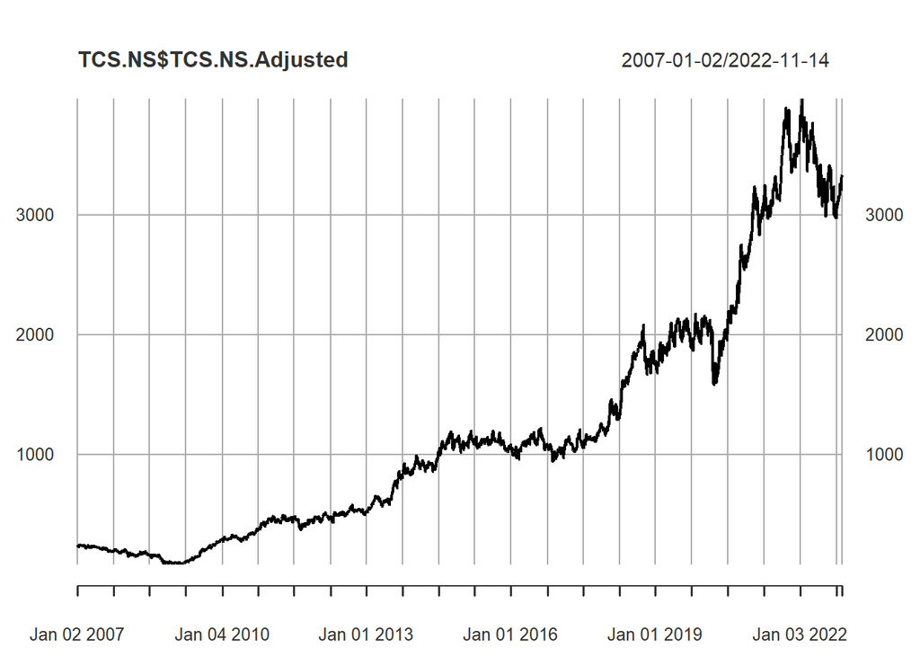

```r
plot(TCS.NS$TCS.NS.Adjusted)
```

**Download the data of market index Nifty50**. The Nifty 50 index indicates how the over all market has done over the similar period.

```r
getSymbols('^NSEI')
```

```
## [1] "^NSEI"
```

```r
tail(NSEI)
```

```
##            NSEI.Open NSEI.High NSEI.Low NSEI.Close NSEI.Volume NSEI.Adjusted
## 2022-11-04  18053.40  18135.10 18017.15   18117.15      267900      18117.15
## 2022-11-07  18211.75  18255.50 18064.75   18202.80      314800      18202.80
## 2022-11-09  18288.25  18296.40 18117.50   18157.00      307200      18157.00
## 2022-11-10  18044.35  18103.10 17969.40   18028.20      256500      18028.20
## 2022-11-11  18272.35  18362.30 18259.35   18349.70      378500      18349.70
## 2022-11-14  18376.40  18399.45 18311.40   18329.15      301400      18329.15
```

Plot the adjusted close value of Nifty50

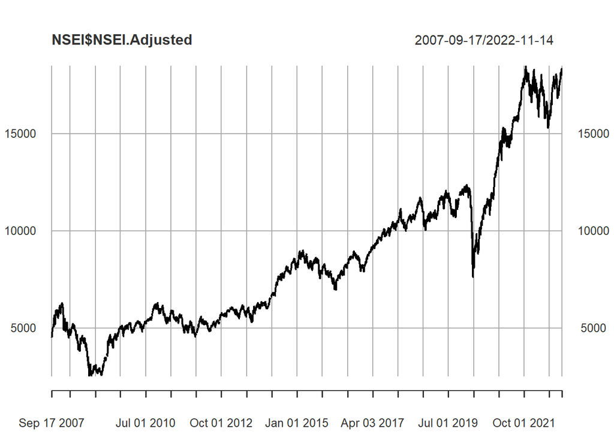

```r
plot(NSEI$NSEI.Adjusted)
```

### Log-Return We calculate the daily log-return, where log-return is defined as
$$r_t=\log(P_t)-\log(P_{t-1})=\Delta \log(P_t),$$
where $P_t$ is the closing price of the stock on $t^{th}$ day.

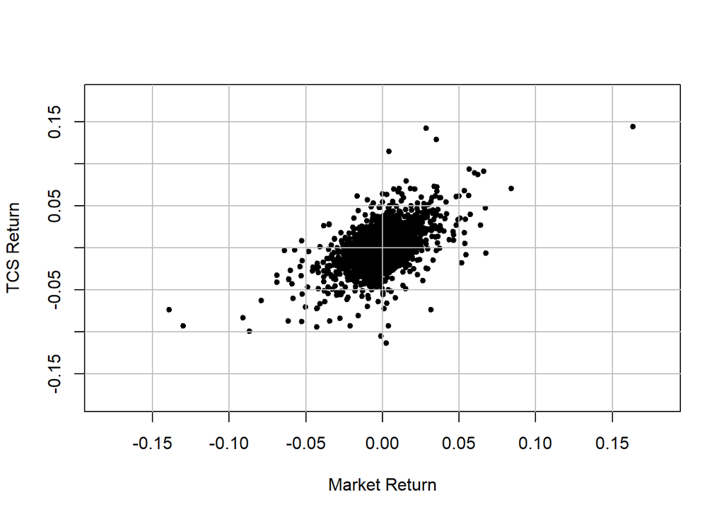

```r
TCS_rt = diff(log(TCS.NS$TCS.NS.Adjusted))
Nifty_rt = diff(log(NSEI$NSEI.Adjusted))
retrn = cbind.xts(TCS_rt,Nifty_rt)
retrn = na.omit(data.frame(retrn))

plot(retrn$NSEI.Adjusted,retrn$TCS.NS.Adjusted
     ,pch=20
     ,xlab='Market Return'
     ,ylab='TCS Return'
     ,xlim=c(-0.18,0.18)
     ,ylim=c(-0.18,0.18))
grid(col='grey',lty=1)
```

+ Consider the following model:

$$r_{t}^{TCS}=\alpha + \beta r_{t}^{Nifty} + \varepsilon,$$
where $\mathbb{E}(\varepsilon)=0$ and $\mathbb{V}ar(\varepsilon)=\sigma^2$.

1. Estimate the parameters of the models $\theta=(\alpha,\beta,\sigma)$ using the method of moments type plug-in estimator discussed in the class.
2. Estimate the parameters using the `lm` built-in function of `R`. Note that `lm` using the OLS method.
3. Fill-up the following table

[output not shown]

4. If the current value of Nifty is 18000 and it goes up to 18200. The current value of TCS is Rs. 3200/-. How much you can expect TCS price to go up?

```r
##Part 1
##Using method of moments in simple linear regression model we have the following eqn
##1->E[Y-alpha-beta*X]=0
##2->E[(Y-alpha-beta*X)*X]=0
##3->E[e^2]=sigma^2
##Solving we get
##beta=cov(x,y)/var(x)
## alpha= E(Y) - beta*E(x)
## sigma=

beta= cov(retrn$NSEI.Adjusted,retrn$TCS.NS.Adjusted)/var(retrn$NSEI.Adjusted)
alpha= mean(retrn$TCS.NS.Adjusted) - beta* mean(retrn$NSEI.Adjusted)
yhat= alpha+beta*retrn$NSEI.Adjusted
sigma=(var(retrn$TCS.NS.Adjusted-yhat))^0.5
sprintf("Estimated value of Alpha: %f",alpha)
```

```
## [1] "Estimated value of Alpha: 0.000463"
```

```r
sprintf("Estimated value of Beta: %f",beta)
```

```
## [1] "Estimated value of Beta: 0.743684"
```

```r
sprintf("Estimated value of sigma: %f",sigma)
```

```
## [1] "Estimated value of sigma: 0.016185"
```

```r
## Part 2
simple_fit = lm(retrn$TCS.NS.Adjusted~retrn$NSEI.Adjusted, data=retrn)
summary(simple_fit)
```

```
##
## Call:
## lm(formula = retrn$TCS.NS.Adjusted ~ retrn$NSEI.Adjusted, data = retrn)
##
## Residuals:
##       Min        1Q    Median        3Q       Max
## -0.115339 -0.008761 -0.000075  0.008538  0.120639
##
## Coefficients:
##                      Estimate Std. Error t value Pr(>|t|)
## (Intercept)         0.0004628  0.0002668   1.734   0.0829 .
## retrn$NSEI.Adjusted 0.7436842  0.0191644  38.806   <2e-16 ***
## ---
## Signif. codes:  0 '***' 0.001 '**' 0.01 '*' 0.05 '.' 0.1 ' ' 1
##
## Residual standard error: 0.01619 on 3680 degrees of freedom
## Multiple R-squared:  0.2904, Adjusted R-squared:  0.2902
## F-statistic:  1506 on 1 and 3680 DF,  p-value: < 2.2e-16
```

```r
##Part 4
r4n=log(18200)-log(18000)
r4t=0.0004628+0.7436838*r4n
x=exp(r4t+log(3200))
sprintf("Expected Price of TCS: %f",x)
```

```
## [1] "Expected Price of TCS: 3227.898137"
```